# A Framework for Accessing Individual Defensive Performance in Coverage

Wei Peng, Marc Richards, Sam Walczak, Jack Werner

1. Introduction  
2. Coverage Type and Defensive Assignemnt

- 2.1 Classifying Coverage Type using K-Means Clustering
- 2.2 Defensive Assignment Identification using Sequential Modeling (IO-HMM)
- 2.3 Combination of K-Means and IO-HMM

3. Evaluation Metrics

- 3.1 In-Play Models
- 3.2 Example Play
- 3.3 After Pass (Targeted Receivers Only) Metrics
- 3.4 Before Pass Metrics

4. Results

- 4.1 Man Coverage
- 4.2 Zone Coverage

5. Conclusion

## 1. Introduction

Current defensive coverage metrics are only calculated on plays where that defender’s assigned offensive player is the one targeted. This approach is flawed and incomplete. On any given play, there are around five available receivers, and the best coverage may prevent the quarterback from even throwing the ball to a given receiver. Further, these metrics identify coverage assignment simply by considering the responsible defender to be the nearest one at the time the ball arrives. Thus, this methodology only gives us coverage assignment for one player per play, and even that assigment is questionable; the closest defender at one particular moment isn’t necessarily the assigned defender.

The work presented here illustrates a framework we’ve developed to address these shortcomings. Our approach begins by identifying the responsibilities of each defender on a given play. If a player is in man (everywhere) coverage, he is assigned a specific offensive player whom he is to cover until the ball is thrown. On the other hand, if a player is in zone coverage, he is instead responsible for an area and any receivers who enter that area. Because the responsibilities of a player differ in each coverage type, the evaluation of performance should be different for each. Once we identify the type of coverage being played by each defender, we then consider two seperate time points for evaluation. For one, we consider the time frame after the pass is thrown. This is the most straightforward, but limits us to only the targeted receivers, as players tend to abandon their assignments and converge to the ball once it is thrown. To include all defenders in our analysis, we also consider the time frame between the snap and the pass. Figure 1 below illustrates our proposed framework for analyzing an individual defensive back’s performance in coverage.

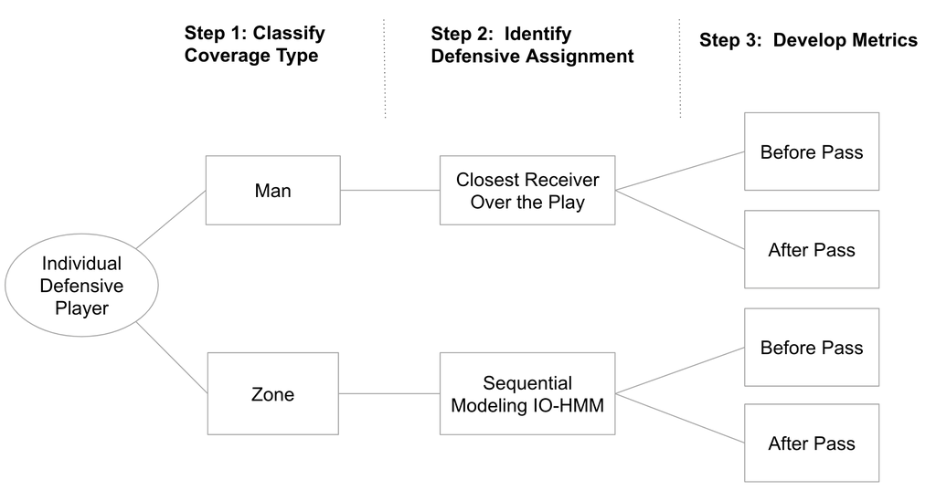

Figure 1. Individual Defensive Player Evaluation Framework

## 2. Coverage Type and Defensive Assignment

This section is broken into two parts: (1) we identify man vs. zone coverage using clustering algorithms, and (2) we introduce Sequential Modeling to identify defensive assignment. The combination of coverage type and defensive assignment provides a full picture of a defensive player’s role in a given play.

#### 2.1 Classifying Coverage Type using K-Means Clustering

We first cluster each defender on each play, similar to the method proposed in dutta2020unsupervised. We use the variables which that paper identified as likely to delineate man coverage from zone coverage: average distance from the nearest teammate and offensive player and variance in position, among others. We also include one of our own variables: the average upfield/downfield component of the orientation vector, as a measure of how “front-facing” the player is on the play. We would expect players in zone coverage to mostly face the line of scrimmage. Man coverage, on the other hand, would often see the opposite, as a defender would run alongside a receiver.

We also tried using a Gaussian Mixture Model to cluster the player-plays, as in dutta2020unsupervised, but we found better results through K-Means clustering. We evaluated our clusters through visualization, using PCA to visualize in two dimensions, then used the PCA loadings and spot-checked extreme cases to identify one cluster as zone coverage and the other as man coverage.

##### 2.2 Defensive Assignment Identification using Sequential Modeling (IO-HMM)

Contrary to basketball, hockey and soccer, man coverage in American football does not typically involve switching players, at least in the traditional sense. Therefore, for players our clustering scheme labels as being in man coverage, we identify the player’s coverage assignment simply as the player they are closest to, on average, over the course of the entire play. A static assignment calls for a simple identification system.

Zone coverage is more complicated, as a player’s assignment may change over the course of a play. We could use a rudimentary method, such as assigning to a defender any offensive player within a given radius. But this approach has its limits. For example, there could be no offensive players within that given radius, or a receiver might be in two defenders’ zones of influence. To model this complexity, we consider a sequential model to identify the defensive assigments at each frame of the play. The simplest way to think of this model is that each defensive player can be in one of six states, where each state represents an offensive player that a defensive player could be covering. As the play evolves over time, the defensive player will transition from state-to-state or stay in the same state (in other words, he could cover different offensive players or the same offensive player) based on the location, orientation and angle of direction of all players.

More formally, let $z_t$ be the player that is being covered by the defensive player at time $t$. Also, let $x_t$ be the information of the defensive player and $\mathrm{X}_t(i)$ be the information of $i$th offensive player. The information includes x-position, y-position, orientation and angle of direction. There are 6 offensive players considered: Quarterback (QB), Wide Receiver 1 (WR_1), Wide Receiver 2 (WR_2), Running Back (RB), Tight End (TE) and Full Back (FB). Denote $\mathrm{X}_t = [\mathrm{X}_t(1),\dots,\mathrm{X}_t(6)]$, and we model $\{z_t, x_t,\mathrm{X}_t\}_0^{T-1}$ by the following equations:

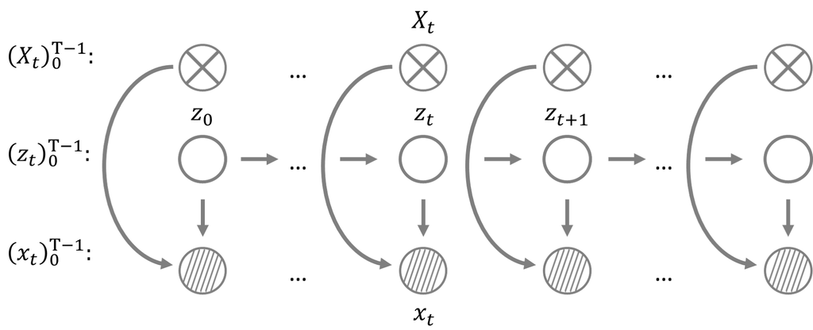

Figure 2. io-hmm defensive assigment

$$\begin{aligned}
\mathbb{P}(z_0 = i) &= \pi_i, \quad i = 1,\dots, 6. \\
\mathbb{P}(z_{t+1}=j\mid z_t = i) &= \zeta_{ij}, \quad i, j = 1, \dots, 6. \\
x_t- \mathrm{X}_t(i) ~|~ \mathrm{X}_t, z_t = i & \sim \mathcal{N}(\mu_i, \Sigma_i), \quad i = 1, \dots, 6,
\end{aligned}$$
where $\pi, \zeta, \mu, \Sigma$ are unkown parameters. This is an instance of Input-Output Hidden Markov Model, first introduced by bengio1995input. In our setting, $\pi_i$ represents that, at time $0$, a defensive player has probability of $\pi_i$ to defend the $i$th offensive player. $\zeta_{ij}$ means that a defensive player has probability of $\zeta_{ij}$ to defend the $j$th offensive player at time $t+1$ given that he defended the $i$th offensive player at time $t$. And $x_t-\mathrm{X}_t(i) \mid \mathrm{X}_t, z_t=i \sim \mathcal{N}(\mu_i, \Sigma_i)$ stands for that given that a defensive player is defending the $i$th offensive player at time $t$, the difference between the infomation of him and that of the $i$th offensive player follows a gaussian distribution with mean $\mu_i$ and variance $\Sigma_i$. Using the Baum-Welch algorithm, we obtain
$$\begin{aligned}
\hat{\pi} & = \begin{bmatrix}
\begin{array}{c|c}
\small{\text{QB}} & \small{0.171} \\
\small{\text{WR_1}} & \small{0.100} \\
\small{\text{WR_2}} & \small{0.099} \\
\small{\text{RB}} & \small{0.152} \\
\small{\text{TE}} & \small{0.398} \\
\small{\text{FB}} & \small{0.080} \\
\end{array}
\end{bmatrix} \quad \text{and} \quad
\hat{\zeta} = \begin{bmatrix}
\begin{array}{c|ccccc}
& \small{\text{QB}} & \small{\text{WR_1}} &\small{\text{WR_2}} &\small{\text{RB}} &\small{\text{TE}} & \small{\text{FB}} \\
\hline
\small{\text{QB}}& \small{\textbf{0.975}}& \small{0.002}& \small{0.003}& \small{0.003}& \small{0.014}& \small{0.002} \\
\small{\text{WR_1}}& \small{0.005}& \small{\textbf{0.981}}& \small{\textit{0.000}}& \small{0.001}& \small{0.007}& \small{0.006} \\
\small{\text{WR_2}}& \small{0.006}& \small{\textit{0.000}}& \small{\textbf{0.975}}& \small{0.005}& \small{0.010}& \small{0.004} \\
\small{\text{RB}}& \small{0.003}& \small{0.001}& 0.002& \small{\textbf{0.985}}& \small{0.009}& \small{0.001} \\
\small{\text{TE}}& \small{0.004}& \small{0.005}& 0.001& \small{0.003}& \small{\textbf{0.984}}& \small{0.003} \\
\small{\text{FB}}& \small{0.001}& \small{0.002}& 0.003& \small{0.001}& \small{0.008}& \small{\textbf{0.985}}& \\
\end{array}
\end{bmatrix}
\end{aligned}.$$
All diagonal entries of $\hat{\zeta}$ are close to one, which agrees with the prior impression that a defensive player typically covers the same offensive player before the ball is in the air. It also makes sense that the probability of switching from defending Wide Receiver 1 to Wide Receiver 2 is $0$ and vice versa. Given the estimated parameters $\hat{\pi}, \hat{\zeta},\hat{\mu}, \hat{\Sigma}$ and the values of $x_t, \mathrm{X}_t$ in a play, we can find the most likely path of the defensive assignment by Viterbi’s Algorithm.

#### 2.3 Combination of K-Means and IO-HMM

Putting it all together, Figure 3 presents a sample play where the defensive players have a line connecting them to the player they are covering at each point in time. Defensive players 22, 21 and 31 are identified as in man coverage and, thus, covering a single receiver the entire play. The rest were identified to be in zone coverage. The defenders in zone experience great variability in their coverage assignment as the play extends. The odd nature of the flee flicker likely contributes to the increased frequency of defensive coverage shifts. Generally, the assignments appear reasonable.

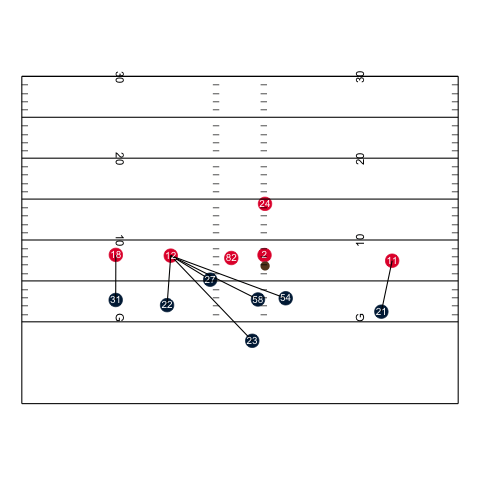

Figure 3. Sample Defensive Assignment

## 3. Evaluation Metrics

In this section, we create four models and propose several metrics to evaluate an individual play. We then assign credit to defenders accordingly. The framework and methodologies for these models are borrowed in part from Burke Deep QB 2017, Yurko continuous in-play model 2019, and Desphande’s and Evans’ Expected Hypothetical Completion Probability 2018.

#### 3.1 In-Play Models

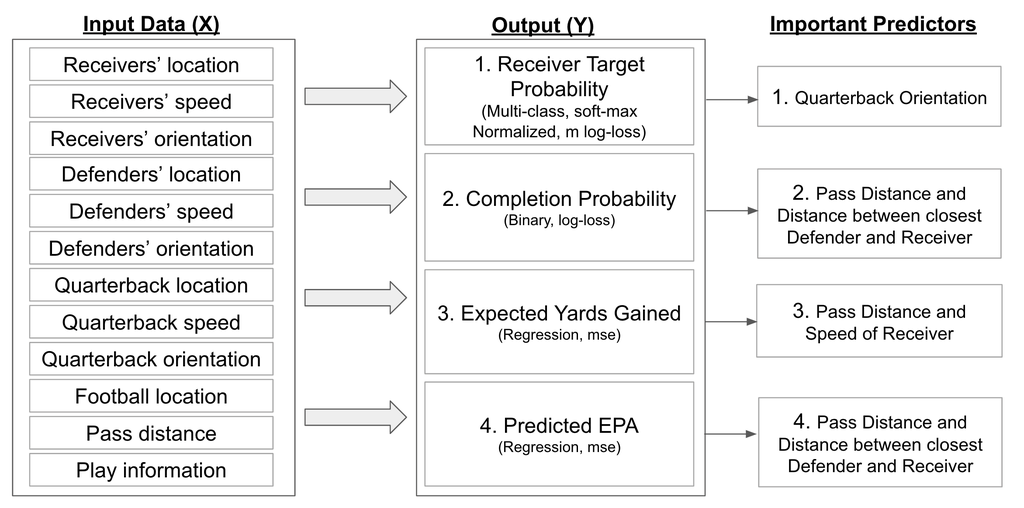

Figure 4. In-play modeling framework. All Input Data is at a specific time or frame on an individual play. Each model variant uses gradient boosted trees via the popular XGBOOST (Chen and Guestrin, 2016). 5-fold cross validation was used to hypertune modeling parameters. Variable importance is derived from the gain.

#### 3.2 Example Play

To illustrate the models, we show the first pass play of the 2018 NFL season: a short Matt Ryan completion to Julio Jones. Figure 5 shows the model predictions at each tenth of a second of the play. The Target Probability Model shows that, at first, the running back, Devonta Freeman, is the most likely target. This makes sense, as Matt Ryan drops back and faces the running back initially. After Ryan is set, it’s clear that Julio Jones was the first read on the play, as the model gives him a high target probability. It also appears to have been a good read, as our Completion Probability Model score for Jones is high at the point the ball was thrown. Also, it’s unsurprising that Freeman and Ortiz running routes out of the backfield had a high completion probability for the entirety of their respective routes. Our Expected Yards Gained and Predicted EPA Models illustrate how, even though the completion probability is high, passing to those players would likely create little value.

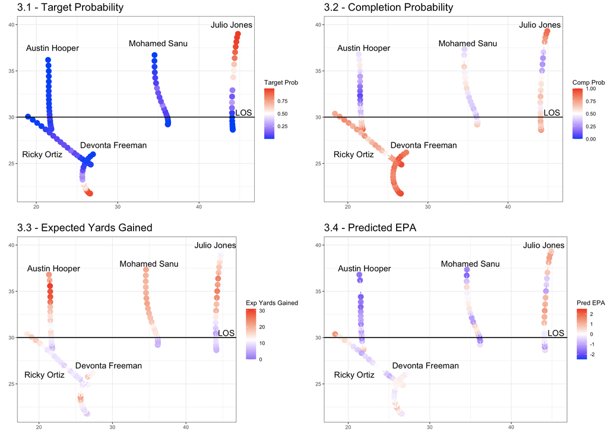

Figure 5. Model Predictions for Sample Play

As noted, one of the most important predictors in our models is the positioning of the defender relative to the receiver. Good coverage would ideally limit these predicted values. Therefore, we can evaluate individual defensive player performance based on the predicted values for the receiver a player is covering.

#### 3.3 After Pass Metrics (Only for Targeted Receivers)

- **Defended Passes Over Expectation (DPOE)** - The probability of completion minus the observed outcome (1 = completed, 0 = incomplete/interception). Remember that the model predicts at the time the ball is released; thus, we can think of DPOE as a proxy for coverage abilities “with the ball in the air.” A higher DPOE is better.
- **Completion Percentage Against (CPA)** - The completion percentage for the receiver(s) a player is covering. A lower value is better.
- **Expected Points Added Against Per Play (EPAA/P)** - The Expected Points Added Per Play by the offense on plays where the defender’s receiver is targeted. A lower value is better.

#### 3.4 Before Pass Metrics

- **Seperation Allowed Over a Play (SEP)** - Seperation in this context is defined as the average Euclidean distance between the defender and the receiver he is covering for a given play. In man coverage, a player’s goal is, generally, to cover a player as closely as possible, and, in fact, the correlation between average seperation on a play and completed pass is roughly 0.2.
- **Expected Completion Probability Against per Play (ECPA/P)** - For a given play, we calculate the average predicted completion probability against before the pass is thrown. The correlation between ECPA and completed pass is roughly 0.32. A lower value is preferred.
- **Predicted Expected Points Added Against Per Play (xEPA/P)** - We define xEPA/P to be the maximum predicted EPA on a given play at any time $t$ before the pass is thrown. The correlation between the Maximum predicted EPA and EPA is roughly 0.4. A lower, negative value is preferred.

## 4. Results

Here we present results and identify some of the best defenders in both man and zone coverages for the 2018 NFL season.

#### 4.1 Man Coverage

| PLAYER | POS | PLAYS | AFTER PASS DPOE | AFTER PASS CPA | AFTER PASS EPAA/P | BEFORE PASS SEP | BEFORE PASS ECPA/P | BEFORE PASS xEPAA/P |
| --- | --- | --- | --- | --- | --- | --- | --- | --- |
| Ahkello Witherspoon | CB | 213 | 3.38 | 0.34 | 0.10 | 3.21 | 0.45 | 1.92 |
| Denzel Ward | CB | 229 | 2.59 | 0.41 | 0.18 | 3.30 | 0.46 | 2.15 |
| Marlon Humphrey | CB | 267 | 2.59 | 0.34 | -0.33 | 2.98 | 0.43 | 2.06 |
| Stephon Gilmore | CB | 404 | 2.18 | 0.35 | -0.29 | 3.04 | 0.45 | 1.94 |
| Patrick Peterson | CB | 253 | 2.10 | 0.42 | 0.41 | 4.28 | 0.49 | 2.16 |
| Steven Nelson | CB | 377 | 1.89 | 0.44 | 0.02 | 2.60 | 0.44 | 2.00 |
| Captain Munnerlyn | CB | 122 | 1.84 | 0.28 | -0.23 | 3.07 | 0.52 | 1.95 |
| Mike Hilton | CB | 117 | 1.60 | 0.43 | -0.21 | 3.68 | 0.51 | 1.98 |
| Jalen Ramsey | CB | 268 | 1.60 | 0.42 | 0.10 | 3.49 | 0.45 | 2.05 |
| Tre'Davious White | CB | 290 | 1.54 | 0.44 | 0.05 | 3.41 | 0.44 | 1.94 |
| Kenny Moore II | CB | 157 | 1.51 | 0.39 | 0.07 | 3.39 | 0.53 | 2.05 |
| Nickell Robey-Coleman | CB | 119 | 1.26 | 0.29 | 0.01 | 3.71 | 0.48 | 2.06 |
| Bryce Callahan | CB | 162 | 1.24 | 0.29 | -0.27 | 3.58 | 0.48 | 1.93 |
| Kareem Jackson | CB | 101 | 1.20 | 0.33 | 0.10 | 4.71 | 0.50 | 2.31 |
| Jonathan Jones | CB | 128 | 1.07 | 0.45 | -0.05 | 3.56 | 0.49 | 2.06 |

DATA SOURCE: NEXT GEN STATS FOR 2018 NFL SEASON

#### 4.2 Zone Coverage

The zone coverage results for the 2018 NFL season are sorted by DPOE below. First, as we would expect, safeties tend to see the most snaps in zone coverage. For example, Ha Ha Clinton-Dix had over 500 plays in zone coverage this past season. By DPOE, Tavon Young, Rafael Bush and Ha Ha Clinton-Dix were among the top defenders in zone coverage. Anthony Levine, Anthony Harris and Minkah Fitzpatrick were also notable performers in zone coverage.

| PLAYER | POS | PLAYS | AFTER PASS DPOE | AFTER PASS CPA | AFTER PASS EPAA/P | BEFORE PASS ECPA/P | BEFORE PASS xEPAA/P |
| --- | --- | --- | --- | --- | --- | --- | --- |
| Tavon Young | CB | 245 | 4.62 | 0.30 | -0.51 | 0.62 | 1.43 |
| Rafael Bush | SS | 187 | 3.41 | 0.35 | -0.23 | 0.69 | 1.45 |
| Ha Ha Clinton-Dix | FS | 512 | 3.41 | 0.34 | -0.09 | 0.59 | 1.49 |
| Anthony Levine | DB | 163 | 3.25 | 0.19 | -0.41 | 0.61 | 1.68 |
| Adoree' Jackson | CB | 280 | 2.91 | 0.47 | -0.11 | 0.63 | 1.55 |
| Marlon Humphrey | CB | 164 | 2.82 | 0.39 | -0.30 | 0.62 | 1.38 |
| Anthony Harris | FS | 269 | 2.66 | 0.38 | -0.24 | 0.62 | 1.52 |
| Corey Graham | FS | 397 | 2.61 | 0.39 | 0.22 | 0.66 | 1.55 |
| Minkah Fitzpatrick | S | 320 | 2.58 | 0.42 | 0.15 | 0.67 | 1.46 |
| Grant Haley | CB | 145 | 2.35 | 0.37 | -0.25 | 0.66 | 1.39 |
| Marcus Gilchrist | FS | 406 | 2.21 | 0.38 | 0.05 | 0.62 | 1.50 |
| Malcolm Butler | CB | 176 | 2.15 | 0.42 | -0.40 | 0.64 | 1.38 |
| Taron Johnson | CB | 184 | 2.06 | 0.35 | -0.17 | 0.65 | 1.50 |
| Micah Hyde | SS | 411 | 1.97 | 0.52 | -0.01 | 0.65 | 1.46 |
| Terrance Mitchell | CB | 179 | 1.90 | 0.54 | -0.31 | 0.69 | 1.38 |

DATA SOURCE: NEXT GEN STATS FOR 2018 NFL SEASON

## 5. Discussion

Expanding beyond traditional defensive evaluation, we provided a simple framework for accessing individual defensive player performance in coverage. We introduced advanced techniques for identifying defensive assignment, particularly in zone coverage over the course of a play. Lastly, we provided a few experimental statistics to evaluate defender performance in man and zone coverages. There are many areas that could be improved. First and foremost, further development of models presented in this notebook. Particularly, defensive assignment. For example, excluding quarterbacks entirely might be a reasonable choice, or inclusion of other positional factors. There may also be room for improvment in identifying man vs. zone (e.g., predicting the coverage type and then infering the individual player coverage type). For NFL personnel, data on the actual coverage type (i.e., man or zone) may already exist, or be easy to get from film. This would greatly improve the analysis, as it would provide a more accurate assignment of man vs. zone. Lastly, there are likely other interesting metrics (related to either coverage types or defender assessment) that could be applied to our framework.